# Quiz3

Kiichi Takeuchi

September 19, 2014

### Q1

Consider the mtcars data set. Fit a model with mpg as the outcome that includes number of cylinders as a factor variable and weight as confounder. Give the adjusted estimate for the expected change in mpg comparing 8 cylinders to 4.

```r
#summary(lm(mpg~cyl+wt,data=mtcars))
fit<-lm(mpg~I(as.factor(cyl))+wt-1,data=mtcars)
fit
```

```
##
## Call:
## lm(formula = mpg ~ I(as.factor(cyl)) + wt - 1, data = mtcars)
##
## Coefficients:
## I(as.factor(cyl))4  I(as.factor(cyl))6  I(as.factor(cyl))8
##              33.99               29.74               27.92
##                 wt
##              -3.21
```

```r
fit<-lm(mpg~I(as.factor(cyl))-1,data=mtcars)
fit
```

```
##
## Call:
## lm(formula = mpg ~ I(as.factor(cyl)) - 1, data = mtcars)
##
## Coefficients:
## I(as.factor(cyl))4  I(as.factor(cyl))6  I(as.factor(cyl))8
##               26.7                19.7                15.1
```

```r
fit<-lm(mpg~
          I(1 * (cyl==4) )
         +I(1 * (cyl==8) )
         +wt
        ,data=mtcars)
fit
```

```
##
## Call:
## lm(formula = mpg ~ I(1 * (cyl == 4)) + I(1 * (cyl == 8)) + wt,
##     data = mtcars)
##
## Coefficients:
##       (Intercept)  I(1 * (cyl == 4))  I(1 * (cyl == 8))
##             29.74               4.26              -1.82
##                wt
##             -3.21
```

```r
fit<-lm(mpg~
          I(1 * (cyl==4) )
         +I(1 * (cyl==8) )
        ,data=mtcars)
fit
```

```
##
## Call:
## lm(formula = mpg ~ I(1 * (cyl == 4)) + I(1 * (cyl == 8)), data = mtcars)
##
## Coefficients:
##       (Intercept)  I(1 * (cyl == 4))  I(1 * (cyl == 8))
##             19.74               6.92              -4.64
```

```r
plot(mtcars[mtcars$cyl==4,]$wt,mtcars[mtcars$cyl==4,]$mpg,col="red",xlim=c(0,5),ylim=c(10,40))
fit1<-lm(mtcars[mtcars$cyl==4,]$mpg~mtcars[mtcars$cyl==4,]$wt)
abline(fit1,col="red")
fit1
```

```
##
## Call:
## lm(formula = mtcars[mtcars$cyl == 4, ]$mpg ~ mtcars[mtcars$cyl ==
##     4, ]$wt)
##
## Coefficients:
##                  (Intercept)  mtcars[mtcars$cyl == 4, ]$wt
##                        39.57                         -5.65
```

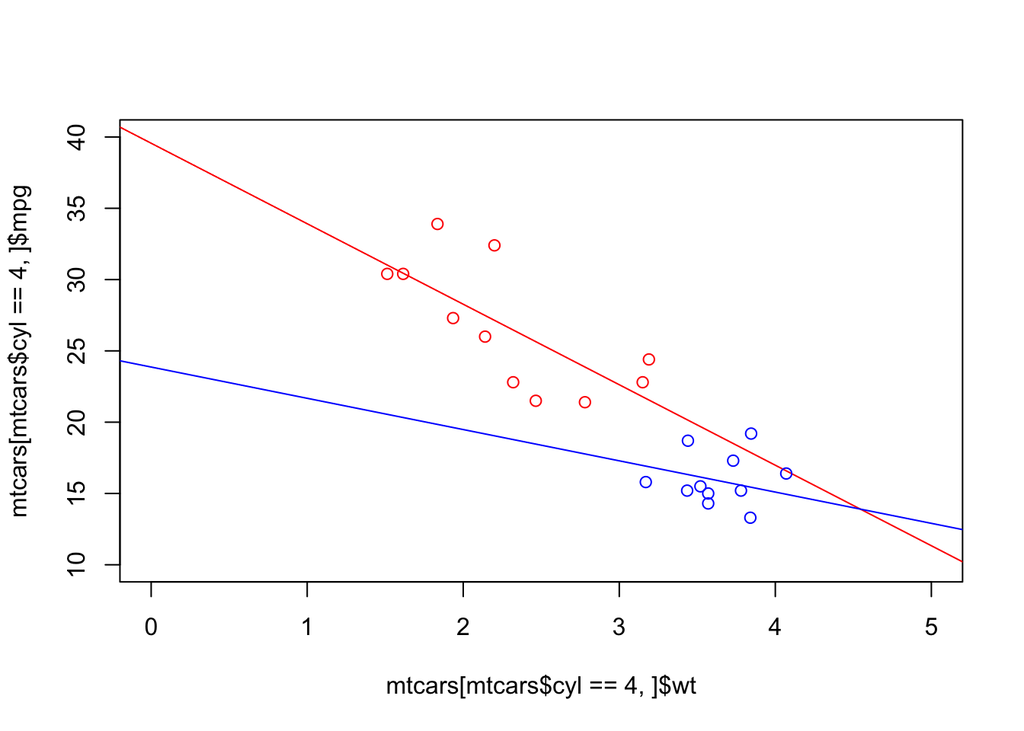

```r
points(mtcars[mtcars$cyl==8,]$wt,mtcars[mtcars$cyl==8,]$mpg,col="blue")
fit2<-lm(mtcars[mtcars$cyl==8,]$mpg~mtcars[mtcars$cyl==8,]$wt)
abline(fit2,col="blue")
```

```r
fit2
```

```
##
## Call:
## lm(formula = mtcars[mtcars$cyl == 8, ]$mpg ~ mtcars[mtcars$cyl ==
##     8, ]$wt)
##
## Coefficients:
##                  (Intercept)  mtcars[mtcars$cyl == 8, ]$wt
##                        23.87                         -2.19
```

```r
#fit0<-lm(mpg~wt,data=mtcars)
#abline(fit0,col="green")
```

### Q2

Compare the adjusted by weight effect of 8 cylinders as compared to 4 the unadjusted. What can be said about the effect?.

```
With Wt: 8->4 diff is 6.07
Without Wt: 8->4 diff 11.56
```

### Q3

Fit a model with mpg as the outcome that considers number of cylinders as a factor variable and weight as confounder. Now fit a second model with mpg as the outcome model that considers the interaction between number of cylinders (as a factor variable) and weight. Give the P-value for the likelihood ratio test comparing the two models and suggest a model using 0.05 as a type I error rate significance benchmark.

```r
# as counfounder (as another varaiable)
fit1<-lm(mpg ~ factor(cyl) + wt, mtcars)
#same (expands like this)
#lm(mpg ~ factor(cyl) + wt + factor(cyl) : wt, mtcars)
summary(fit1)$coef
```

```
##              Estimate Std. Error t value  Pr(>|t|)
## (Intercept)    33.991     1.8878  18.006 6.257e-17
## factor(cyl)6   -4.256     1.3861  -3.070 4.718e-03
## factor(cyl)8   -6.071     1.6523  -3.674 9.992e-04
## wt             -3.206     0.7539  -4.252 2.130e-04
```

```r
#star means interaction
fit2<-lm(mpg ~ factor(cyl) * wt, mtcars)
summary(fit2)$coef
```

```
##                 Estimate Std. Error t value  Pr(>|t|)
## (Intercept)       39.571      3.194 12.3895 2.058e-12
## factor(cyl)6     -11.162      9.355 -1.1932 2.436e-01
## factor(cyl)8     -15.703      4.839 -3.2448 3.223e-03
## wt                -5.647      1.359 -4.1538 3.128e-04
## factor(cyl)6:wt    2.867      3.117  0.9197 3.662e-01
## factor(cyl)8:wt    3.455      1.627  2.1229 4.344e-02
```

```r
anova(fit1,fit2)
```

```
## Analysis of Variance Table
##
## Model 1: mpg ~ factor(cyl) + wt
## Model 2: mpg ~ factor(cyl) * wt
##   Res.Df RSS Df Sum of Sq    F Pr(>F)
## 1     28 183
## 2     26 156  2      27.2 2.27   0.12
```

Model #2 with interaction of weight is not significant; that is, we failed reject null hypthosis since p-value is 0.12 > 0.05.

### Q4

```r
fit<-lm(mpg ~ I(wt * 0.5) + factor(cyl), data = mtcars)
summary(fit)$coef
```

```
##              Estimate Std. Error t value  Pr(>|t|)
## (Intercept)    33.991      1.888  18.006 6.257e-17
## I(wt * 0.5)    -6.411      1.508  -4.252 2.130e-04
## factor(cyl)6   -4.256      1.386  -3.070 4.718e-03
## factor(cyl)8   -6.071      1.652  -3.674 9.992e-04
```

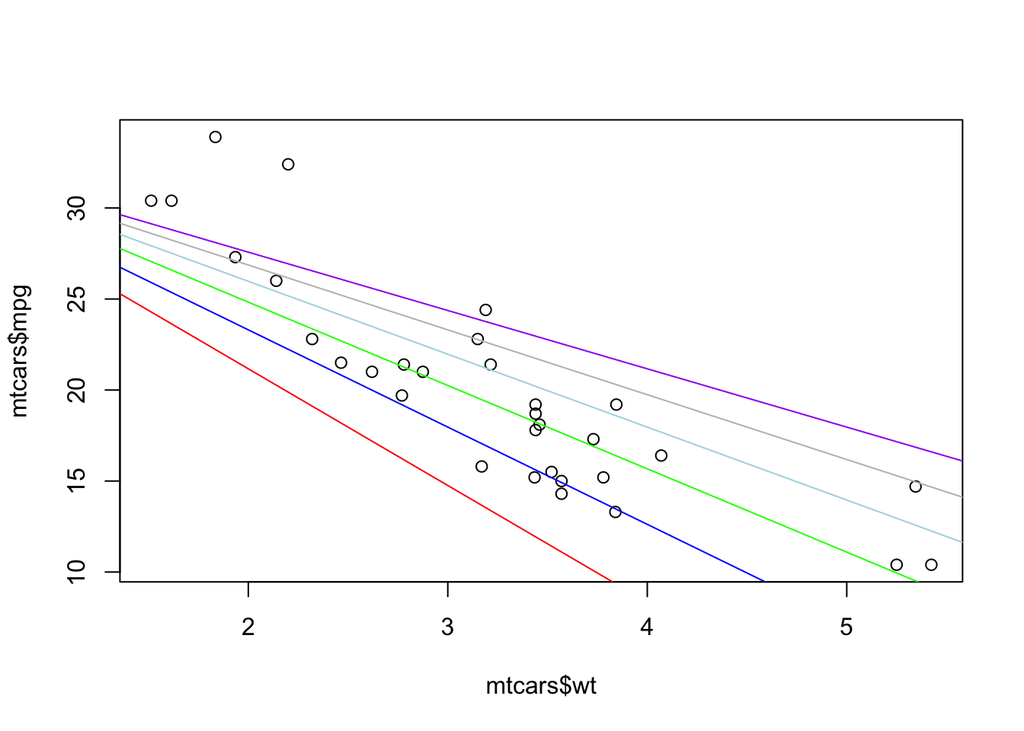

```r
plot(mtcars$wt,mtcars$mpg)
abline(fit,col="red")
abline(lm(mpg ~ I(wt * 0.6) + factor(cyl), data = mtcars),col="blue")
abline(lm(mpg ~ I(wt * 0.7) + factor(cyl), data = mtcars),col="green")
abline(lm(mpg ~ I(wt * 0.8) + factor(cyl), data = mtcars),col="lightblue")
abline(lm(mpg ~ I(wt * 0.9) + factor(cyl), data = mtcars),col="gray")
abline(lm(mpg ~ I(wt * 1.0) + factor(cyl), data = mtcars),col="purple")
```

### Q5

Give the hat diagonal for the most influential point

See Video 02_04_c Residuals and diagnostics examples 6:32

```r
x <- c(0.586, 0.166, -0.042, -0.614, 11.72)
y <- c(0.549, -0.026, -0.127, -0.751, 1.344)
fit<-lm(y~x)

hatvalues(fit)
```

```
##      1      2      3      4      5
## 0.2287 0.2438 0.2525 0.2804 0.9946
```

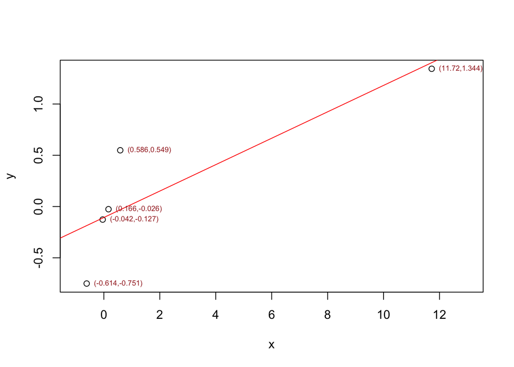

```r
plot(x,y,xlim=c(-1,13))
abline(fit,col="red")
text(x, y,sprintf("(%s,%s)",x,y), cex=0.6, pos=4, col="brown")
```

### Q6

Give the slope dfbeta for the point with the highest hat value.

Note: dfbetas shows values if you take out the data, how much the impact would be?

hatvalues is potential infulence within the dataset

See Video 02_04_c Residuals and diagnostics examples 6:32

```r
dfbetas(fit)
```

```
##   (Intercept)          x
## 1     1.06212 -3.781e-01
## 2     0.06748 -2.862e-02
## 3    -0.01736  7.915e-03
## 4    -1.24958  6.725e-01
## 5     0.20432 -1.338e+02
```

### Q7

Consider a regression relationship between Y and X with and without adjustment for a third variable Z. Which of the following is true about comparing the regression coefficient between Y and X with and without adjustment for Z.